# Plastic Pirates EU Analsysis

# Paper’s Skeleton

The idea is to have two papers Questions to be solved

- Calification/descualification rate
  - We need to analyse the raw data in order to have those sampling events that were qualified and which doesn’t (RiversideWasteVariety_AttemptedSampling == 1 and RiversideWasteVariety_Qualified == 1)

# Community-based approach to analyze composition of litter

# Look for explanatory variables inside the dataset from Plastic Pirates. (se está dejando para después)

# Include extra-explanatory variables for all the variables will be nice if something else can take care on this.

# Next meeting before the Workshop on Data Validation/Consolidation and Analysis.

## Focused in the general aspect of data (Types, Kg, Zones, etc.)

# We have to include the informaton of group D (look at quantitative/semi-quantitative data)

# Data Analysis

## Loading Packages

Loading R packages necessary to perform the **EDA**.

```r
library(tidyverse)
library(readxl)
library(writexl)
library(DT)
library(lubridate)
library(scales)
library(vegan)       # decostand(), rda(), adonis2()
library(factoextra)  # fviz_pca_biplot(), fviz_dend()
library(randomForest)
library(RColorBrewer)
library(tidyHeatmap) # Requieres ComplexHeatmap --> BiocManager::install("ComplexHeatmap")
```

## Data loading

```r
# Cargamos los datos incorporando las modificaciones para trabajar con él
# https://zenodo.org/records/15535434
# Cuidado con el nombre de los ríos, hay besòs y bessos.
Riverbank <-
  read.csv(file = "PlasticPirates_Riverbank_data/Riverbank_data_v2.0.0.csv", header = TRUE, sep = ",", na.strings = "na") %>%
  mutate(SamplingDate = lubridate::ymd(SamplingDate)) %>%
  mutate(across(where(is.character), as.factor))
```

## Pre-proccessing

```r
# Loading the rivers' dictionary
Riverbank_dictionary <- read_excel("Riverbank_data_v2.1.xlsx", sheet = "Final vocabulary clean")

Riverbank <-
  Riverbank %>%
  left_join(Riverbank_dictionary, by = "SamplingRiver") %>%
    #select(SamplingRiver, Corrected_river_English, SamplingRiverSystem, River_basin, everything()) %>%
    mutate(River_basin = str_remove(River_basin, regex("\\s+Basin$", ignore_case = TRUE))) %>%
  mutate(SamplingRiver = coalesce(Corrected_river_English, SamplingRiver),
         SamplingRiverSystem = River_basin) %>%
  select(-c("No", "Country", "Corrected_river", "Corrected_river_English", "River_basin", "Count of SamplingRiver"))
```

## RESEARCH QUESTIONS

### Citizens Description

#### Numer of samplings per year and country

- Table

```r
Riverbank %>%
  group_by(CountryResponsible, SamplingYear) %>%
  summarise(Num_Sampling = n())
```

| CountryResponsible | SamplingYear | Num_Sampling |
| --- | --- | --- |
| austria | 2021 | 1 |
| austria | 2022 | 17 |
| austria | 2023 | 58 |
| austria | 2024 | 66 |
| belgium | 2022 | 22 |
| belgium | 2024 | 31 |
| bulgaria | 2023 | 10 |
| germany | 2022 | 75 |
| germany | 2023 | 11 |
| germany | 2024 | 6 |

[output cut: 19 more lines]

- Plot

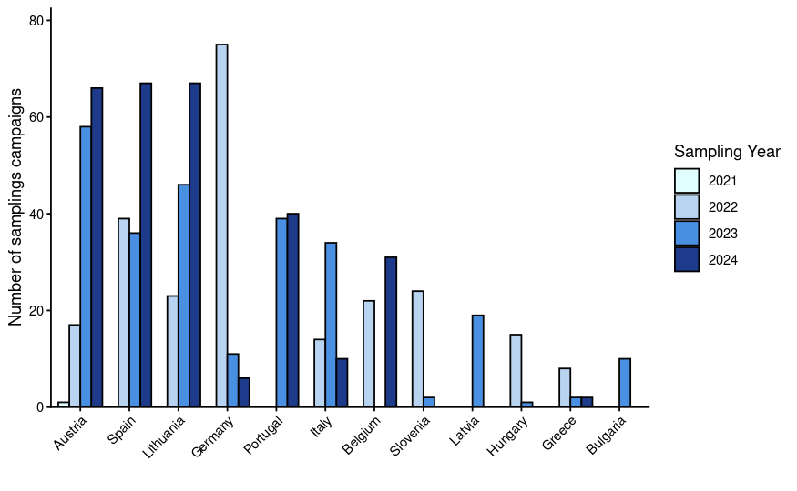

#### Numer of Rivers sampled per year and country

- Table

```r
Riverbank %>%
  group_by(CountryResponsible, SamplingYear) %>%
  summarise(Rivers = n_distinct(SamplingRiver))
```

| CountryResponsible | SamplingYear | Rivers |
| --- | --- | --- |
| austria | 2021 | 1 |
| austria | 2022 | 10 |
| austria | 2023 | 35 |
| austria | 2024 | 35 |
| belgium | 2022 | 12 |
| belgium | 2024 | 18 |
| bulgaria | 2023 | 1 |
| germany | 2022 | 58 |
| germany | 2023 | 10 |
| germany | 2024 | 5 |

[output cut: 19 more lines]

- Plot (without numbers)

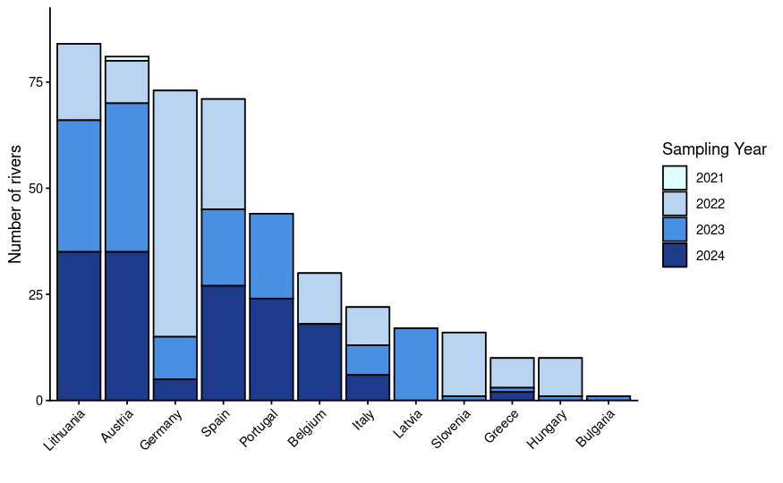

```r
Riverbank %>%
  group_by(CountryResponsible, SamplingYear) %>%
  summarise(Rivers = n_distinct(SamplingRiver), .groups = 'drop') %>%
  # Capitalizar primera letra de cada país
  mutate(CountryResponsible = str_to_title(CountryResponsible)) %>%
  # Crear todas las combinaciones posibles de país y año
  complete(CountryResponsible, SamplingYear, fill = list(Rivers = 0)) %>%
  # Ordenar por total acumulado de ríos
  mutate(CountryResponsible = reorder(CountryResponsible, -Rivers, sum)) %>%
  ggplot(aes(x = CountryResponsible, y = Rivers, fill = factor(SamplingYear))) +
  geom_bar(stat = "identity", position = "stack", colour = 'black') +
  theme_classic() +
  theme(axis.text.x = element_text(angle = 45, hjust = 1)) +
  # Paleta de colores con intensidad creciente hacia 2024
  scale_fill_manual(values = c("2021" = "#E0FFFF", "2022" = "#B8D4F0", "2023" = "#4A90E2", "2024" = "#1E3A8A")) +
  scale_y_continuous(expand = expansion(mult = c(0, 0.1))) +
  labs(x = "",
       y = "Number of rivers",
       fill = "Sampling Year")
```

- Plot (with numbers)

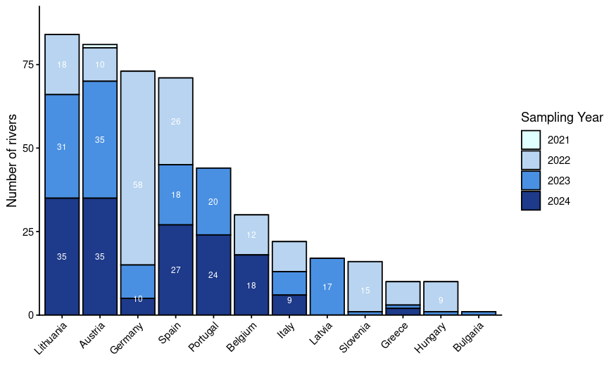

### Most common types and quantities of litter per region? (Group B: riverbanks; Group C: floating litter)

#### Group B: Riverside Waste

Statistics of the variable `RiversideWasteVariety_AttemptedSampling` to see how many samplings were performed.

```r
Riverbank %>%
  select(RiversideWasteVariety_AttemptedSampling) %>%
  table()
```

```
RiversideWasteVariety_AttemptedSampling
  0   1
 27 756
```

To work with the `RiversideWasteVariety_` data, we need to filter the dataset to include only those rows where `RiversideWasteVariety_AttemptedSampling` is 1 (indicating that a sampling was attempted) and `RiversideWasteVariety_Qualified` is also 1 (indicating that the sampling was qualified).

```r
Riverbank %>%
  filter(RiversideWasteVariety_AttemptedSampling == 1 & RiversideWasteVariety_Qualified == 1)
```

| file.source | DatasetID | CountryResponsible | ResearchInstituteResponsible | PersonResponsible | PersonContact | GeneralCommentDataset | SamplingCampaign | SamplingYear | SamplingTeamName | SamplingInstitution | SamplingAttempted | DatasetReasonDisqualified | DatasetQualified | SamplingOnlineOnWebsite | SamplingDate | SamplingCoordinatesLatitude | SamplingCoordinatesLongitude | SamplingPlace | SamplingRegion | SamplingRiver | SamplingRiverSystem | SamplingParticipants | SamplingComment | RiversideLitterCircles_AttemptedSampling | RiversideLitterCircles_DisqualifiedReason | RiversideLitterCircles_Qualified | RiversideLitterCircles_Results_NumberOfStationsSampled | RiversideLitterCircles_Results_NumberOfStationsWithLitterFindings | RiversideLitterCircles_Results_PaperTotal | … |
| --- | --- | --- | --- | --- | --- | --- | --- | --- | --- | --- | --- | --- | --- | --- | --- | --- | --- | --- | --- | --- | --- | --- | --- | --- | --- | --- | --- | --- | --- | --- |
| austria_verified_data_plasticpirates_autumn2022.xlsx | at_6270 | austria | institute of waste management and circularity (abf-boku) | anna noichl; magdalena kraml | anna.noichl@boku.ac.at; magdalena.kraml@boku.ac.at | NA | autumn 2022 | 2022 | bgr-pirates | bgr steyr | 1 | NA | 1 | 1 | 2022-10-18 | 48.04275 | 14.4219170 | steyr | oberösterreich | Steyr River | Danube | 9 | NA | 0 | NA | NA | NA | NA | NA | … |
| austria_verified_data_plasticpirates_autumn2022.xlsx | at_6297 | austria | institute of waste management and circularity (abf-boku) | anna noichl; magdalena kraml | anna.noichl@boku.ac.at; magdalena.kraml@boku.ac.at | NA | autumn 2022 | 2022 | die roten drachen | jugendrotkreuz braunau | 1 | NA | 1 | 1 | 2022-10-22 | 48.26034 | 13.0344048 | braunau am inn | oberösterreich | Inn River | Danube | 8 | NA | 1 | groups with inexplicable differences between litter counts and material composition on photographs upon comparison to submitted data sheets | 0 | NA | NA | NA | … |
| austria_verified_data_plasticpirates_autumn2022.xlsx | at_6382 | austria | institute of waste management and circularity (abf-boku) | anna noichl; magdalena kraml | anna.noichl@boku.ac.at; magdalena.kraml@boku.ac.at | NA | autumn 2022 | 2022 | future team hak tamsweg | hak tamsweg | 1 | NA | 1 | 1 | 2022-11-08 | 47.11828 | 13.8141908 | tamsweg | salzburg | Mur River | Danube | 20 | NA | 1 | no photos available | 0 | NA | NA | NA | … |
| austria_verified_data_plasticpirates_autumn2022.xlsx | at_6393 | austria | institute of waste management and circularity (abf-boku) | anna noichl; magdalena kraml | anna.noichl@boku.ac.at; magdalena.kraml@boku.ac.at | NA | autumn 2022 | 2022 | hlsp villach | höhere lehranstalt für sozialbetreuung und pflege | 1 | NA | 1 | 1 | 2022-11-09 | 46.58301 | 13.8411527 | villach | kärnten | Gail River | Danube | 38 | NA | 1 | NA | 1 | 9 | 7 | 20 | … |
| austria_verified_data_plasticpirates_autumn2022.xlsx | at_6429 | austria | institute of waste management and circularity (abf-boku) | anna noichl; magdalena kraml | anna.noichl@boku.ac.at; magdalena.kraml@boku.ac.at | NA | autumn 2022 | 2022 | bg9 | bg9 wasagasse | 1 | NA | 1 | 1 | 2022-11-08 | 48.21108 | 16.4397350 | wien stadlau | wien | Danube River | Danube | 20 | NA | 1 | NA | 1 | 9 | 9 | 10 | … |
| austria_verified_data_plasticpirates_autumn2022.xlsx | at_6429 | austria | institute of waste management and circularity (abf-boku) | anna noichl; magdalena kraml | anna.noichl@boku.ac.at; magdalena.kraml@boku.ac.at | NA | autumn 2022 | 2022 | bg9 | bg9 wasagasse | 1 | NA | 1 | 1 | 2022-11-08 | 48.21108 | 16.4397350 | wien stadlau | wien | Danube River | Danube | 20 | NA | 1 | NA | 1 | 9 | 9 | 10 | … |
| austria_verified_data_plasticpirates_autumn2022.xlsx | at_6448 | austria | institute of waste management and circularity (abf-boku) | anna noichl; magdalena kraml | anna.noichl@boku.ac.at; magdalena.kraml@boku.ac.at | NA | autumn 2022 | 2022 | adventistische privatschule klagenfurt | adventistische privatschule klagenfurt | 1 | NA | 1 | 1 | 2022-11-11 | 46.60477 | 14.2780000 | klagenfurt | kärnten | Sattnitz River | Danube | 16 | NA | 1 | NA | 1 | 9 | 3 | 0 | … |
| austria_verified_data_plasticpirates_autumn2022.xlsx | at_6463 | austria | institute of waste management and circularity (abf-boku) | anna noichl; magdalena kraml | anna.noichl@boku.ac.at; magdalena.kraml@boku.ac.at | NA | autumn 2022 | 2022 | stitch_6b | bg schwechat | 1 | NA | 1 | 1 | 2022-11-21 | 48.12415 | 16.8521211 | petronell-carnuntum | niederösterreich | Danube River | Danube | 20 | NA | 1 | groups with inexplicable differences between litter counts and material composition on photographs upon comparison to submitted data sheets | 0 | NA | NA | NA | … |
| austria_verified_data_plasticpirates_autumn2022.xlsx | at_6463 | austria | institute of waste management and circularity (abf-boku) | anna noichl; magdalena kraml | anna.noichl@boku.ac.at; magdalena.kraml@boku.ac.at | NA | autumn 2022 | 2022 | stitch_6b | bg schwechat | 1 | NA | 1 | 1 | 2022-11-21 | 48.12415 | 16.8521211 | petronell-carnuntum | niederösterreich | Danube River | Danube | 20 | NA | 1 | groups with inexplicable differences between litter counts and material composition on photographs upon comparison to submitted data sheets | 0 | NA | NA | NA | … |
| austria_verified_data_plasticpirates_autumn2022.xlsx | at_6536 | austria | institute of waste management and circularity (abf-boku) | anna noichl; magdalena kraml | anna.noichl@boku.ac.at; magdalena.kraml@boku.ac.at | NA | autumn 2022 | 2022 | gymgmunden | bg/brg gmunden | 1 | NA | 1 | 1 | 2022-12-07 | 47.92751 | 13.7992560 | gmunden | oberösterreich | Traun River | Danube | 6 | NA | 1 | NA | 1 | 9 | 5 | 0 | … |

[output cut: 541 more lines]

##### Percentage of qualified samplings

```r
Riverbank %>%
  summarise(
    total_rows = n(),
    total_valid = sum(
      RiversideWasteVariety_AttemptedSampling == 1 &
      RiversideWasteVariety_Qualified == 1,
      na.rm = TRUE
    ),
    pct_valid_total = round((total_valid / total_rows) * 100, digits = 1),
    pct_valid_percent = paste(round((total_valid / total_rows) * 100, 1), "%", sep = "")
  )
```

| total_rows | total_valid | pct_valid_total | pct_valid_percent |
| --- | --- | --- | --- |
| 785 | 551 | 70.2 | 70.2% |

```r
validated_pct_by_country <-
  Riverbank %>%
  group_by(CountryResponsible) %>%
  summarise(total_rows = n(),
            total_valid = sum(RiversideWasteVariety_AttemptedSampling == 1 & RiversideWasteVariety_Qualified == 1, na.rm = TRUE),
    `pct_valid_total(%)`        = round((total_valid / total_rows) * 100,1),
    total_attempts         = sum(RiversideWasteVariety_AttemptedSampling == 1, na.rm = TRUE),
    valid_among_attempts   = sum(RiversideWasteVariety_AttemptedSampling == 1 & RiversideWasteVariety_Qualified == 1, na.rm = TRUE),
    `pct_valid_among_attempts(%)` = round((valid_among_attempts / total_attempts) * 100,1), .groups = "drop") %>%
  mutate(CountryResponsible = str_to_title(CountryResponsible))

validated_pct_by_country
```

| CountryResponsible | total_rows | total_valid | pct_valid_total(%) | total_attempts | valid_among_attempts | pct_valid_among_attempts(%) |
| --- | --- | --- | --- | --- | --- | --- |
| Austria | 142 | 74 | 52.1 | 128 | 74 | 57.8 |
| Belgium | 53 | 49 | 92.5 | 52 | 49 | 94.2 |
| Bulgaria | 10 | 10 | 100.0 | 10 | 10 | 100.0 |
| Germany | 92 | 86 | 93.5 | 91 | 86 | 94.5 |
| Greece | 12 | 11 | 91.7 | 11 | 11 | 100.0 |
| Hungary | 16 | 15 | 93.8 | 16 | 15 | 93.8 |
| Italy | 58 | 51 | 87.9 | 55 | 51 | 92.7 |
| Latvia | 19 | 10 | 52.6 | 19 | 10 | 52.6 |
| Lithuania | 136 | 90 | 66.2 | 133 | 90 | 67.7 |
| Portugal | 79 | 45 | 57.0 | 77 | 45 | 58.4 |

[output cut: 2 more lines]

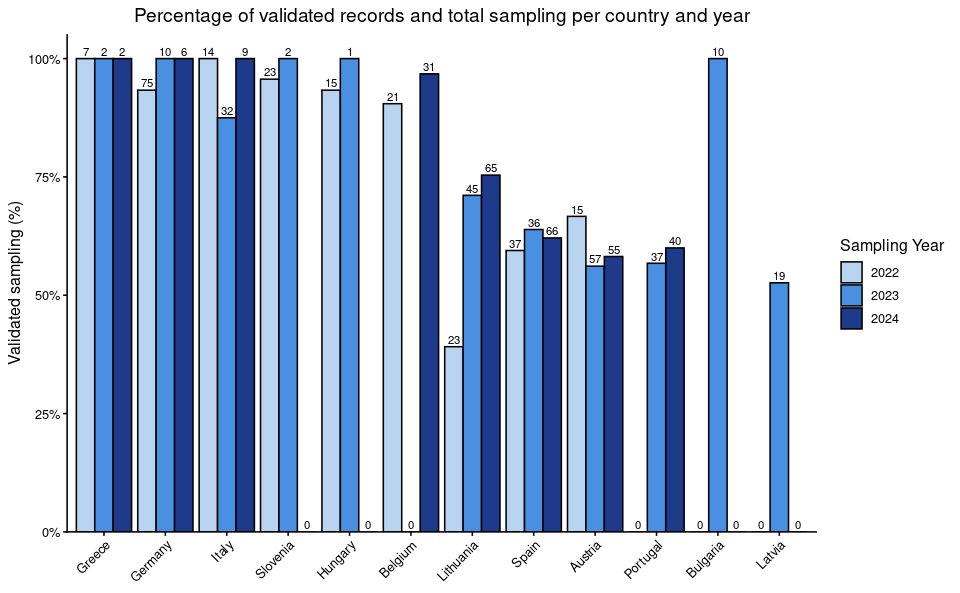

```r
Riverbank %>%
  group_by(CountryResponsible, SamplingYear) %>%
  summarise(
    n_attempted = sum(RiversideWasteVariety_AttemptedSampling == 1, na.rm = TRUE),
    n_validated = sum(RiversideWasteVariety_AttemptedSampling == 1 & RiversideWasteVariety_Qualified == 1, na.rm = TRUE),
    pct_validated = if_else(n_attempted > 0, n_validated / n_attempted * 100, 0),
    .groups = "drop"
  ) %>%
  mutate(CountryResponsible = str_to_title(CountryResponsible)) %>%
  complete(CountryResponsible, SamplingYear,
           fill = list(n_attempted   = 0,
                       n_validated   = 0,
                       pct_validated = 0)
  ) %>%
  filter(SamplingYear > 2021)  %>%
  mutate(CountryResponsible = reorder(CountryResponsible,-pct_validated, FUN = mean)) %>%
  ggplot(aes(
    x    = CountryResponsible,
    y    = pct_validated,
    fill = factor(SamplingYear)
  )) +
    geom_col(
      position = "dodge",
      colour  = "black"
    ) +
  geom_text(aes(label = n_attempted),
              position = position_dodge(width = 0.9),
              vjust    = -0.3,
              size     = 3
    ) +
  # geom_text(aes(label = paste0("(", n_attempted, ")")),
  #           position = position_dodge(width = 0.9),
  #           vjust    = -0.3,
  #           size     = 2.8) +
    scale_fill_manual(
      values = c(
        "2021" = "#E0FFFF",
        "2022" = "#B8D4F0",
        "2023" = "#4A90E2",
        "2024" = "#1E3A8A"
      ),
      name = "Sampling Year"
    ) +
    scale_y_continuous(
      labels = percent_format(scale = 1),
      expand = expansion(mult = c(0, 0.05))
    ) +
    labs(
      x     = NULL,
      y     = "Validated sampling (%)",
      title = "Percentage of validated records and total sampling per country and year"
    ) +
    theme_classic(base_size = 12) +
    theme(
      axis.text.x = element_text(angle = 45, hjust = 1),
      plot.title  = element_text(hjust = 0.5)
    )
```

##### Most common types/quantities of litter

```r
Riverbank %>%
  filter(RiversideWasteVariety_AttemptedSampling == 1 & RiversideWasteVariety_Qualified == 1)
```

| file.source | DatasetID | CountryResponsible | ResearchInstituteResponsible | PersonResponsible | PersonContact | GeneralCommentDataset | SamplingCampaign | SamplingYear | SamplingTeamName | SamplingInstitution | SamplingAttempted | DatasetReasonDisqualified | DatasetQualified | SamplingOnlineOnWebsite | SamplingDate | SamplingCoordinatesLatitude | SamplingCoordinatesLongitude | SamplingPlace | SamplingRegion | SamplingRiver | SamplingRiverSystem | SamplingParticipants | SamplingComment | RiversideLitterCircles_AttemptedSampling | RiversideLitterCircles_DisqualifiedReason | RiversideLitterCircles_Qualified | RiversideLitterCircles_Results_NumberOfStationsSampled | RiversideLitterCircles_Results_NumberOfStationsWithLitterFindings | RiversideLitterCircles_Results_PaperTotal | … |
| --- | --- | --- | --- | --- | --- | --- | --- | --- | --- | --- | --- | --- | --- | --- | --- | --- | --- | --- | --- | --- | --- | --- | --- | --- | --- | --- | --- | --- | --- | --- |
| austria_verified_data_plasticpirates_autumn2022.xlsx | at_6270 | austria | institute of waste management and circularity (abf-boku) | anna noichl; magdalena kraml | anna.noichl@boku.ac.at; magdalena.kraml@boku.ac.at | NA | autumn 2022 | 2022 | bgr-pirates | bgr steyr | 1 | NA | 1 | 1 | 2022-10-18 | 48.04275 | 14.4219170 | steyr | oberösterreich | Steyr River | Danube | 9 | NA | 0 | NA | NA | NA | NA | NA | … |
| austria_verified_data_plasticpirates_autumn2022.xlsx | at_6297 | austria | institute of waste management and circularity (abf-boku) | anna noichl; magdalena kraml | anna.noichl@boku.ac.at; magdalena.kraml@boku.ac.at | NA | autumn 2022 | 2022 | die roten drachen | jugendrotkreuz braunau | 1 | NA | 1 | 1 | 2022-10-22 | 48.26034 | 13.0344048 | braunau am inn | oberösterreich | Inn River | Danube | 8 | NA | 1 | groups with inexplicable differences between litter counts and material composition on photographs upon comparison to submitted data sheets | 0 | NA | NA | NA | … |
| austria_verified_data_plasticpirates_autumn2022.xlsx | at_6382 | austria | institute of waste management and circularity (abf-boku) | anna noichl; magdalena kraml | anna.noichl@boku.ac.at; magdalena.kraml@boku.ac.at | NA | autumn 2022 | 2022 | future team hak tamsweg | hak tamsweg | 1 | NA | 1 | 1 | 2022-11-08 | 47.11828 | 13.8141908 | tamsweg | salzburg | Mur River | Danube | 20 | NA | 1 | no photos available | 0 | NA | NA | NA | … |
| austria_verified_data_plasticpirates_autumn2022.xlsx | at_6393 | austria | institute of waste management and circularity (abf-boku) | anna noichl; magdalena kraml | anna.noichl@boku.ac.at; magdalena.kraml@boku.ac.at | NA | autumn 2022 | 2022 | hlsp villach | höhere lehranstalt für sozialbetreuung und pflege | 1 | NA | 1 | 1 | 2022-11-09 | 46.58301 | 13.8411527 | villach | kärnten | Gail River | Danube | 38 | NA | 1 | NA | 1 | 9 | 7 | 20 | … |
| austria_verified_data_plasticpirates_autumn2022.xlsx | at_6429 | austria | institute of waste management and circularity (abf-boku) | anna noichl; magdalena kraml | anna.noichl@boku.ac.at; magdalena.kraml@boku.ac.at | NA | autumn 2022 | 2022 | bg9 | bg9 wasagasse | 1 | NA | 1 | 1 | 2022-11-08 | 48.21108 | 16.4397350 | wien stadlau | wien | Danube River | Danube | 20 | NA | 1 | NA | 1 | 9 | 9 | 10 | … |
| austria_verified_data_plasticpirates_autumn2022.xlsx | at_6429 | austria | institute of waste management and circularity (abf-boku) | anna noichl; magdalena kraml | anna.noichl@boku.ac.at; magdalena.kraml@boku.ac.at | NA | autumn 2022 | 2022 | bg9 | bg9 wasagasse | 1 | NA | 1 | 1 | 2022-11-08 | 48.21108 | 16.4397350 | wien stadlau | wien | Danube River | Danube | 20 | NA | 1 | NA | 1 | 9 | 9 | 10 | … |
| austria_verified_data_plasticpirates_autumn2022.xlsx | at_6448 | austria | institute of waste management and circularity (abf-boku) | anna noichl; magdalena kraml | anna.noichl@boku.ac.at; magdalena.kraml@boku.ac.at | NA | autumn 2022 | 2022 | adventistische privatschule klagenfurt | adventistische privatschule klagenfurt | 1 | NA | 1 | 1 | 2022-11-11 | 46.60477 | 14.2780000 | klagenfurt | kärnten | Sattnitz River | Danube | 16 | NA | 1 | NA | 1 | 9 | 3 | 0 | … |
| austria_verified_data_plasticpirates_autumn2022.xlsx | at_6463 | austria | institute of waste management and circularity (abf-boku) | anna noichl; magdalena kraml | anna.noichl@boku.ac.at; magdalena.kraml@boku.ac.at | NA | autumn 2022 | 2022 | stitch_6b | bg schwechat | 1 | NA | 1 | 1 | 2022-11-21 | 48.12415 | 16.8521211 | petronell-carnuntum | niederösterreich | Danube River | Danube | 20 | NA | 1 | groups with inexplicable differences between litter counts and material composition on photographs upon comparison to submitted data sheets | 0 | NA | NA | NA | … |
| austria_verified_data_plasticpirates_autumn2022.xlsx | at_6463 | austria | institute of waste management and circularity (abf-boku) | anna noichl; magdalena kraml | anna.noichl@boku.ac.at; magdalena.kraml@boku.ac.at | NA | autumn 2022 | 2022 | stitch_6b | bg schwechat | 1 | NA | 1 | 1 | 2022-11-21 | 48.12415 | 16.8521211 | petronell-carnuntum | niederösterreich | Danube River | Danube | 20 | NA | 1 | groups with inexplicable differences between litter counts and material composition on photographs upon comparison to submitted data sheets | 0 | NA | NA | NA | … |
| austria_verified_data_plasticpirates_autumn2022.xlsx | at_6536 | austria | institute of waste management and circularity (abf-boku) | anna noichl; magdalena kraml | anna.noichl@boku.ac.at; magdalena.kraml@boku.ac.at | NA | autumn 2022 | 2022 | gymgmunden | bg/brg gmunden | 1 | NA | 1 | 1 | 2022-12-07 | 47.92751 | 13.7992560 | gmunden | oberösterreich | Traun River | Danube | 6 | NA | 1 | NA | 1 | 9 | 5 | 0 | … |

[output cut: 541 more lines]

```r
NA
```

Firstly, we will pick up data to answer the question about group B. Only some variables are taken from the general dataset.

```r
# GroupB dataset
GroupB_data <-
  Riverbank %>%
  select(DatasetID, CountryResponsible, SamplingCampaign, SamplingYear, SamplingCoordinatesLatitude, SamplingCoordinatesLongitude, SamplingRiverSystem, SamplingParticipants, RiversideWasteVariety_AttemptedSampling, RiversideWasteVariety_Qualified:RiversideWasteVariety_Results_ResultsComment)
```

The, Attributes’ names are so complicated to work that I’ll remote the preceding information **RiversideWasteVariety_Results_** which is common to all attributes; and finally to work with only the validated `Group B` dataset we create:

```r
# GroupB dataset
GroupB_data_validated <-
  Riverbank %>%
  select(DatasetID, CountryResponsible, SamplingCampaign, SamplingYear, SamplingCoordinatesLatitude, SamplingCoordinatesLongitude, SamplingRiverSystem, SamplingParticipants, RiversideWasteVariety_AttemptedSampling, RiversideWasteVariety_Qualified:RiversideWasteVariety_Results_ResultsComment) %>%
  filter(RiversideWasteVariety_AttemptedSampling == 1 & RiversideWasteVariety_Qualified == 1) %>%
  # Primero quitamos `RiversideWasteVariety_Results_`
  rename_with(
    .cols = starts_with("RiversideWasteVariety_Results_"),
    # solo seleccionamos los tipos de residuos
    .fn = ~ gsub("RiversideWasteVariety_Results_", "", .) # Mantenemos la ultima extensión del nombre
  )

GroupB_data_validated
```

| DatasetID | CountryResponsible | SamplingCampaign | SamplingYear | SamplingCoordinatesLatitude | SamplingCoordinatesLongitude | SamplingRiverSystem | SamplingParticipants | RiversideWasteVariety_AttemptedSampling | RiversideWasteVariety_Qualified | PlasticBags | PlasticBottles | PlasticLids | TakeawayFastFood | PlasticCutleryPlates | PlasticPackagingSweets | CottonBuds | WetWipesSanitaryProducts | Polystyrene | SingleUsePlasticTotal | SmallPlasticPieces.2.5cm | OtherUnidentifiablePlastic | MetalBeverageCans | BottleCaps | AluminiumFoil | OtherUnidentifiableMetal | GlassBottles | GlassPieces | OtherUnidentifiableGlass | CigaretteButts | … |
| --- | --- | --- | --- | --- | --- | --- | --- | --- | --- | --- | --- | --- | --- | --- | --- | --- | --- | --- | --- | --- | --- | --- | --- | --- | --- | --- | --- | --- | --- | --- |
| at_6270 | austria | autumn 2022 | 2022 | 48.04275 | 14.4219170 | Danube | 9 | 1 | 1 | 2 | 0 | 0 | 2 | 0 | 1 | 0 | 1 | 0 | 6 | 0 | 5 | 1 | 5 | 2 | 57 | 1 | 50 | 0 | 10 | … |
| at_6297 | austria | autumn 2022 | 2022 | 48.26034 | 13.0344048 | Danube | 8 | 1 | 1 | NA | 1 | 4 | 1 | 1 | 14 | NA | 3 | NA | 24 | 7 | 28 | 4 | 11 | 18 | 8 | 1 | 2 | NA | 73 | … |
| at_6382 | austria | autumn 2022 | 2022 | 47.11828 | 13.8141908 | Danube | 20 | 1 | 1 | 0 | 0 | 0 | 0 | 0 | 2 | 0 | 0 | 1 | 3 | 2 | 7 | 0 | 1 | 1 | 3 | 0 | 0 | 0 | 2 | … |
| at_6393 | austria | autumn 2022 | 2022 | 46.58301 | 13.8411527 | Danube | 38 | 1 | 1 | 34 | 22 | 13 | 2 | NA | 34 | NA | NA | NA | NA | NA | 23 | 38 | 28 | 53 | 14 | 17 | 25 | NA | 179 | … |
| at_6429 | austria | autumn 2022 | 2022 | 48.21108 | 16.4397350 | Danube | 20 | 1 | 1 | 7 | 22 | 17 | 9 | 3 | 10 | 2 | 7 | 6 | 83 | 11 | 2 | 23 | 6 | 6 | 6 | 13 | 51 | 0 | 39 | … |
| at_6429 | austria | autumn 2022 | 2022 | 48.21108 | 16.4397350 | Danube | 20 | 1 | 1 | 7 | 22 | 17 | 9 | 3 | 10 | 2 | 7 | 6 | 83 | 11 | 2 | 23 | 6 | 6 | 6 | 13 | 51 | 0 | 39 | … |
| at_6448 | austria | autumn 2022 | 2022 | 46.60477 | 14.2780000 | Danube | 16 | 1 | 1 | 3 | 4 | 1 | 3 | 0 | 1 | 0 | 0 | 0 | 13 | 0 | 9 | 13 | 1 | 3 | 2 | 7 | 8 | 0 | 2 | … |
| at_6463 | austria | autumn 2022 | 2022 | 48.12415 | 16.8521211 | Danube | 20 | 1 | 1 | 0 | 16 | 13 | 1 | 0 | 37 | 0 | 1 | 25 | 93 | 65 | 39 | 3 | 0 | 2 | 2 | 4 | 8 | 0 | 1 | … |
| at_6463 | austria | autumn 2022 | 2022 | 48.12415 | 16.8521211 | Danube | 20 | 1 | 1 | 0 | 16 | 13 | 1 | 0 | 37 | 0 | 1 | 25 | 93 | 65 | 39 | 3 | 0 | 2 | 2 | 4 | 8 | 0 | 1 | … |
| at_6536 | austria | autumn 2022 | 2022 | 47.92751 | 13.7992560 | Danube | 6 | 1 | 1 | 0 | 1 | 1 | 1 | 1 | 2 | 0 | 0 | 0 | 6 | 0 | 2 | 4 | 2 | 1 | 3 | 0 | 0 | 0 | 0 | … |

[output cut: 541 more lines]

**CAUTION**! There are some `NAs` values in the litter items that are probably incorrect since the groups did find other items.

```r
summary(GroupB_data_validated)
```

```
   DatasetID   CountryResponsible    SamplingCampaign  SamplingYear  SamplingCoordinatesLatitude
 at_6429:  2   lithuania: 90      autumn 2021:  0     Min.   :2022   Min.   :37.18
 at_6463:  2   germany  : 86      autumn 2022:198     1st Qu.:2022   1st Qu.:42.03
 at_6972:  2   spain    : 86      autumn 2023:144     Median :2023   Median :48.07
 at_6977:  2   austria  : 74      autumn 2024: 50     Mean   :2023   Mean   :47.47
 de_6237:  2   italy    : 51      spring 2022:  1     3rd Qu.:2024   3rd Qu.:51.33
 de_6457:  2   belgium  : 49      spring 2023: 26     Max.   :2024   Max.   :57.75
 (Other):539   (Other)  :115      spring 2024:132
 SamplingCoordinatesLongitude SamplingRiverSystem SamplingParticipants RiversideWasteVariety_AttemptedSampling
 Min.   :-9.309               Length:551          Min.   :  2.00       Min.   :1
 1st Qu.: 2.946               Class :character    1st Qu.: 13.00       1st Qu.:1
 Median :12.331               Mode  :character    Median : 19.00       Median :1
 Mean   :10.912                                   Mean   : 19.58       Mean   :1
 3rd Qu.:16.923                                   3rd Qu.: 24.00       3rd Qu.:1
 Max.   :27.488                                   Max.   :250.00       Max.   :1
                                                  NA's   :10
 RiversideWasteVariety_Qualified  PlasticBags      PlasticBottles     PlasticLids      TakeawayFastFood
 Min.   :1                       Min.   :  0.000   Min.   :  0.000   Min.   :  0.000   Min.   :  0.000
 1st Qu.:1                       1st Qu.:  0.000   1st Qu.:  0.000   1st Qu.:  0.000   1st Qu.:  0.000
 Median :1                       Median :  3.000   Median :  1.000   Median :  1.000   Median :  1.000
 Mean   :1                       Mean   :  7.547   Mean   :  6.392   Mean   :  4.005   Mean   :  2.853
 3rd Qu.:1                       3rd Qu.:  7.000   3rd Qu.:  4.000   3rd Qu.:  4.000   3rd Qu.:  3.000
 Max.   :1                       Max.   :196.000   Max.   :576.000   Max.   :115.000   Max.   :102.000
                                 NA's   :3         NA's   :5         NA's   :2         NA's   :5
 PlasticCutleryPlates PlasticPackagingSweets   CottonBuds       WetWipesSanitaryProducts  Polystyrene
 Min.   : 0.000       Min.   :  0.00         Min.   :  0.0000   Min.   :   0.00          Min.   :  0.000
 1st Qu.: 0.000       1st Qu.:  1.00         1st Qu.:  0.0000   1st Qu.:   0.00          1st Qu.:  0.000
 Median : 0.000       Median :  4.00         Median :  0.0000   Median :   0.00          Median :  0.000
 Mean   : 1.063       Mean   : 10.04         Mean   :  0.7402   Mean   :  12.24          Mean   :  6.672
 3rd Qu.: 1.000       3rd Qu.: 12.00         3rd Qu.:  0.0000   3rd Qu.:   2.00          3rd Qu.:  2.000
 Max.   :49.000       Max.   :121.00         Max.   :145.0000   Max.   :1897.00          Max.   :423.000
 NA's   :10           NA's   :3              NA's   :16         NA's   :12               NA's   :9
 SingleUsePlasticTotal SmallPlasticPieces.2.5cm OtherUnidentifiablePlastic MetalBeverageCans   BottleCaps
 Min.   :   0.00       Min.   :  0.000          Min.   :  0.00             Min.   :  0.000   Min.   :  0.000
 1st Qu.:  10.00       1st Qu.:  0.000          1st Qu.:  0.00             1st Qu.:  0.000   1st Qu.:  0.000
 Median :  21.50       Median :  0.000          Median :  3.00             Median :  1.000   Median :  0.000
 Mean   :  50.45       Mean   :  9.485          Mean   : 12.18             Mean   :  4.655   Mean   :  4.589
 3rd Qu.:  49.75       3rd Qu.:  6.250          3rd Qu.: 12.00             3rd Qu.:  4.000   3rd Qu.:  3.000
 Max.   :1997.00       Max.   :939.000          Max.   :463.00             Max.   :207.000   Max.   :201.000
 NA's   :1             NA's   :11               NA's   :5                  NA's   :3         NA's   :6
```

[output cut: 25 more lines]

```
 0.3    : 14          0      :  9
 0      : 13          0.6    :  6
 1      : 11          1      :  6
 0.05   :  9          3.2    :  6
 0.1    :  9          NA     :  6
 (Other):462          (Other):491
 NA's   : 33          NA's   : 27
                                                                           ResultsComment
 weight from homepage                                                             : 11
 the group calculated the proportion single-use-plastics wrong, so we corrected it:  6
 no                                                                               :  5
 little differences between photos and data                                       :  4
 mismatch photos and weight                                                       :  4
 (Other)                                                                          :156
 NA's                                                                             :365
```

After meeting and email fro Charlotte, we realise that NA in group B for some items it’s really a zero. So we update these columns replacing `NA` values with a `0`.

```r
GroupB_data_validated <-
  GroupB_data_validated %>%
  mutate(across(PlasticBags:LocalWaste, ~replace_na(., 0)))
```

###### Litter type abundance

We will obtain the plot for the most common (average abundance) litter type

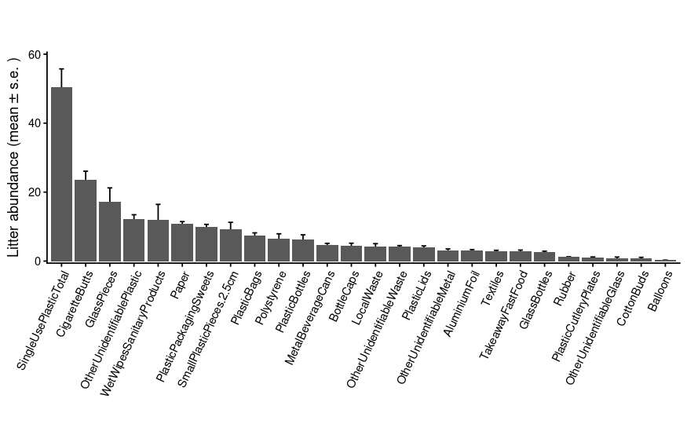

###### Litter type abundance per country

If we now want to visualize the contribution per each country, we have:

[figure not shown]

###### Litter type Proportion I - “Across‑type” proportions

- The first approach will be a “*Across‑type*” proportions.
  - For each litter type, what fraction comes from each country? (not from an european total)
  - total abundance of that litter type over each total country.

```r
Prop_Liter_Country <-
  GroupB_data_validated %>%
  # 1) pivot to long form
  pivot_longer(
    cols      = PlasticBags:LocalWaste,
    names_to  = "Litter_type",
    values_to = "Abundance"
  ) %>%
  # 2) sum abundance by (Country, Type)
  group_by(CountryResponsible, Litter_type) %>%
  summarise(
    Total_Abundance = sum(Abundance, na.rm = TRUE),
    .groups = "drop"
  ) %>%
  # 3) compute, per type, the global total
  group_by(Litter_type) %>%
  mutate(
    Global_Total   = sum(Total_Abundance),
    Prop_Country   = Total_Abundance / Global_Total
  ) %>%
  ungroup()

Prop_Liter_Country
```

| CountryResponsible | Litter_type | Total_Abundance | Global_Total | Prop_Country |
| --- | --- | --- | --- | --- |
| austria | AluminiumFoil | 246 | 1636 | 0.1503667482 |
| austria | Balloons | 12 | 126 | 0.0952380952 |
| austria | BottleCaps | 503 | 2501 | 0.2011195522 |
| austria | CigaretteButts | 2915 | 12962 | 0.2248881345 |
| austria | CottonBuds | 6 | 396 | 0.0151515152 |
| austria | GlassBottles | 209 | 1462 | 0.1429548564 |
| austria | GlassPieces | 2364 | 9527 | 0.2481368741 |
| austria | LocalWaste | 146 | 2343 | 0.0623132736 |
| austria | MetalBeverageCans | 383 | 2551 | 0.1501372011 |
| austria | OtherUnidentifiableGlass | 3 | 462 | 0.0064935065 |

[output cut: 302 more lines]

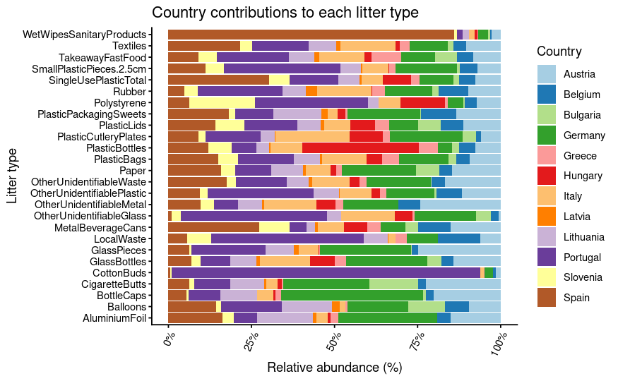

- Now, considering the total of Europe

```r
# 1) Pivot, sum by country & type, then compute each country’s share of the European total
Data_prop_eu <-
  GroupB_data_validated %>%
  pivot_longer(
    cols      = PlasticBags:LocalWaste,
    names_to  = "Litter_type",
    values_to = "Abundance"
  ) %>%
  group_by(CountryResponsible, Litter_type) %>%
  summarise(
    Total_Abundance = sum(Abundance, na.rm = TRUE),
    .groups = "drop"
  ) %>%
  group_by(Litter_type) %>%
  mutate(
    European_Total   = sum(Total_Abundance),
    Prop_of_Europe   = Total_Abundance / European_Total
  ) %>%
  ungroup() %>%
  # optional: title‑case and reorder types by overall Prop for consistent ordering
  mutate(
    CountryResponsible = str_to_title(CountryResponsible),
    Litter_type        = reorder(Litter_type, -Prop_of_Europe)
  )

Data_prop_eu
```

| CountryResponsible | Litter_type | Total_Abundance | European_Total | Prop_of_Europe |
| --- | --- | --- | --- | --- |
| Austria | AluminiumFoil | 246 | 1636 | 0.1503667482 |
| Austria | Balloons | 12 | 126 | 0.0952380952 |
| Austria | BottleCaps | 503 | 2501 | 0.2011195522 |
| Austria | CigaretteButts | 2915 | 12962 | 0.2248881345 |
| Austria | CottonBuds | 6 | 396 | 0.0151515152 |
| Austria | GlassBottles | 209 | 1462 | 0.1429548564 |
| Austria | GlassPieces | 2364 | 9527 | 0.2481368741 |
| Austria | LocalWaste | 146 | 2343 | 0.0623132736 |
| Austria | MetalBeverageCans | 383 | 2551 | 0.1501372011 |
| Austria | OtherUnidentifiableGlass | 3 | 462 | 0.0064935065 |

[output cut: 302 more lines]

To compare and validate the output, for each `litter_type` the `European_Total` have to be the same.

```r
# To compare and validate the output, for each `litter_type` the `European_Total` have to be the same.
Data_prop_eu %>%
  filter(Litter_type == "AluminiumFoil")
```

| CountryResponsible | Litter_type | Total_Abundance | European_Total | Prop_of_Europe |
| --- | --- | --- | --- | --- |
| Austria | AluminiumFoil | 246 | 1636 | 0.1503667482 |
| Belgium | AluminiumFoil | 67 | 1636 | 0.0409535452 |
| Bulgaria | AluminiumFoil | 1 | 1636 | 0.0006112469 |
| Germany | AluminiumFoil | 486 | 1636 | 0.2970660147 |
| Greece | AluminiumFoil | 36 | 1636 | 0.0220048900 |
| Hungary | AluminiumFoil | 17 | 1636 | 0.0103911980 |
| Italy | AluminiumFoil | 53 | 1636 | 0.0323960880 |
| Latvia | AluminiumFoil | 17 | 1636 | 0.0103911980 |
| Lithuania | AluminiumFoil | 275 | 1636 | 0.1680929095 |
| Portugal | AluminiumFoil | 115 | 1636 | 0.0702933985 |

[output cut: 2 more lines]

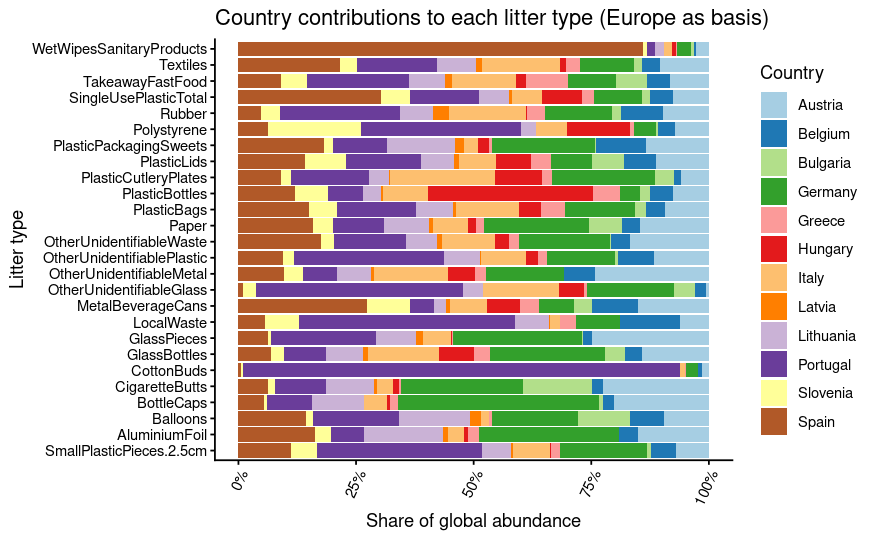

```r
# Example 100%-stacked bar
Data_prop_eu %>%
mutate(CountryResponsible = str_to_title(CountryResponsible)) %>%
ggplot(., aes(x = Litter_type, y = Prop_of_Europe, fill = CountryResponsible)) +
  geom_col(position = "fill") +
  scale_y_continuous(labels = percent_format()) +
  scale_fill_manual(
    values = brewer.pal(12, "Paired"),
    name   = "Country"
  ) +
  labs(
    x = "Litter type",
    y = "Share of global abundance",
    title = "Country contributions to each litter type (Europe as basis)"
  ) +
  theme_classic() +
  theme(axis.text.x = element_text(angle = 65, hjust = 1)) +
  coord_flip()
```

[figure not shown]

```r
#x11()
# 2) Faceted bar chart of proportion (country share of European total)
# 2) plot with fixed scales and text labels
ggplot(Data_prop_eu, aes(x = Litter_type, y = Prop_of_Europe)) +
  geom_col(fill = "lightgray", colour = "black") +
  geom_text( # comment if you don't need the numbers above the bars
    #aes(label = percent(Prop_of_Europe, accuracy = 0.1), suffix = "%"),
    aes(label = round((Prop_of_Europe*100), 1)),
    angle   = 45,       # rotate labels 45°
    hjust   = 0,        # left‑align text relative to its anchor
    vjust   = -0.3,     # nudge it a bit above the bar
    size  = 2.7          # adjust text size as needed
  ) +
  scale_y_continuous(
    labels = percent_format(accuracy = 1),
    expand = expansion(mult = c(0, 0.15))  # extra 15% headroom for labels
  ) +
  facet_wrap(~ CountryResponsible, ncol = 3, scales = "fixed") +
  labs(
    x        = NULL,
    y        = "Share of European total (%)",
    title    = "Country contributions to each litter type",
    subtitle = "Proportion of European total abundance for each category"
  ) +
  theme_classic(base_size = 14) +
  theme(
    axis.text.x      = element_text(angle = 65, hjust = 1),
    strip.background = element_rect(fill = "lightgrey", colour = "black"),
    strip.text       = element_text(face = "bold")
  )
```

- HeatMaps

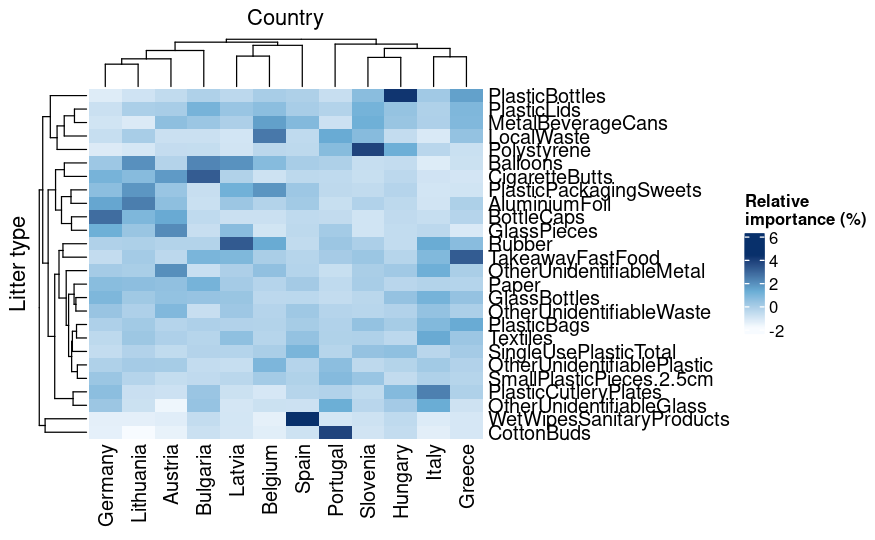

###### Litter type Proportion II - “Within‑country” proportions

- The second approach will be a “*Within‑country*” proportions.
  - For each country, what fraction of its total litter is each type?
  - Total abundance of all types in that country.

```r
Prop_Liter_Country2 <-
  GroupB_data_validated %>%
  # 1) pivot to long
  pivot_longer(
    cols      = PlasticBags:LocalWaste,
    names_to  = "Litter_type",
    values_to = "Abundance"
  ) %>%
  # 2) sum by (Country, Type)
  group_by(CountryResponsible, Litter_type) %>%
  summarise(
    Total_Abundance = sum(Abundance, na.rm = TRUE),
    .groups = "drop"
  ) %>%
  # 3) compute, per country, that country’s total
  group_by(CountryResponsible) %>%
  mutate(
    Country_Total = sum(Total_Abundance),
    Prop_Type     = Total_Abundance / Country_Total
  ) %>%
  ungroup()

Prop_Liter_Country2
```

| CountryResponsible | Litter_type | Total_Abundance | Country_Total | Prop_Type |
| --- | --- | --- | --- | --- |
| austria | AluminiumFoil | 246 | 14179 | 1.734960e-02 |
| austria | Balloons | 12 | 14179 | 8.463220e-04 |
| austria | BottleCaps | 503 | 14179 | 3.547500e-02 |
| austria | CigaretteButts | 2915 | 14179 | 2.055857e-01 |
| austria | CottonBuds | 6 | 14179 | 4.231610e-04 |
| austria | GlassBottles | 209 | 14179 | 1.474011e-02 |
| austria | GlassPieces | 2364 | 14179 | 1.667254e-01 |
| austria | LocalWaste | 146 | 14179 | 1.029692e-02 |
| austria | MetalBeverageCans | 383 | 14179 | 2.701178e-02 |
| austria | OtherUnidentifiableGlass | 3 | 14179 | 2.115805e-04 |

[output cut: 302 more lines]

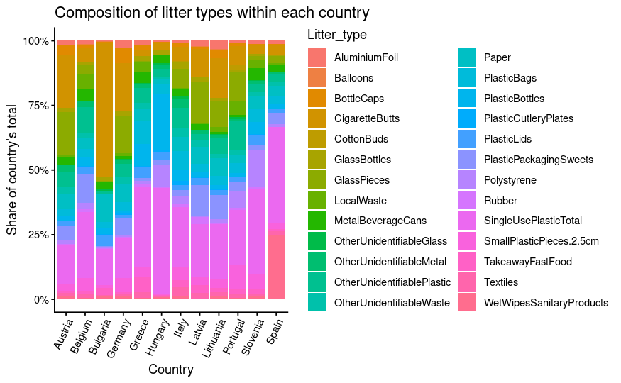

```r
# Example 100%-stacked bar per country
Prop_Liter_Country2 %>%
mutate(CountryResponsible = str_to_title(CountryResponsible)) %>%
ggplot(., aes(x = CountryResponsible, y = Prop_Type, fill = Litter_type)) +
  geom_col(position = "fill") +
  scale_y_continuous(labels = percent_format()) +
  labs(
    x = "Country",
    y = "Share of country’s total",
    title = "Composition of litter types within each country"
  ) +
  theme_classic() +
  theme(axis.text.x = element_text(angle = 65, hjust = 1))
```

[figure not shown]

```r
  # 2) plot bars first, then error bars
Prop_Liter_Country2 %>%
  # 1) group by country AND type
  group_by(CountryResponsible, Litter_type) %>%
  summarise(
    Av_Proportion = mean(Prop_Type, na.rm = TRUE),
    SE_Proportion = sd(Prop_Type,   na.rm = TRUE) / sqrt(n()),
    .groups = "drop"
  ) %>%
  # title‐case country, reorder types by their overall mean if you like
  mutate(
    CountryResponsible = str_to_title(CountryResponsible),
    Litter_type       = reorder(Litter_type, -Av_Proportion)
  ) %>%
  ggplot(data = ., aes(x = Litter_type, y = Av_Proportion)) +
  geom_col(fill = "lightgray", colour = "black") +
  geom_errorbar(aes(ymin = Av_Proportion - SE_Proportion,
                    ymax = Av_Proportion + SE_Proportion), width = 0.2) +
  facet_wrap(~ CountryResponsible, ncol   = 3, scales = "free_y") +
  labs(x = "", y = "Litter abundance (mean)", title = '', subtitle = "") +
  # theme_classic() +
  # theme(axis.text.x = element_text(angle = 65, vjust = 1, hjust = 1)) +
  theme_classic(base_size = 16) +
  theme(
    # rotate axis labels, center title, etc.
    axis.text.x     = element_text(angle = 65, hjust = 1),
    plot.title      = element_text(hjust = 0.5),
    strip.background = element_rect(
      fill   = "lightgrey",  # background color
      color  = "black",      # border color
      size   = 0.5           # border thickness
    ),
    strip.text       = element_text(
      colour = "black",      # text color
      face   = "bold"        # make it stand out
    )
  )
```

###### Multivariate Perspective

```r
# assume your data is in a data.frame called `df`
# and has at least:
#   CountryResponsible | PlasticBags | PlasticBottles | ... | LocalWaste
# Replace the NA values for 0. --> Probably the default behaviour?
df <- GroupB_data_validated %>%
  select(CountryResponsible, PlasticBags:LocalWaste)
# %>%
# #drop_na()
# mutate_all(funs(replace_na(.,0)))

# isolate metadata + community matrix
meta <- df %>% select(CountryResponsible)
comm <- df %>% select(-CountryResponsible)

# Hellinger‐transform community data (recommended for PCA/cluster/PERMANOVA)
comm_hel <- decostand(comm, method = "hellinger")
```

In order to see if there are significant differences across country in the community composition, we will perform a PERMANOVA test:

```r
# 2a) Compute distance and hierarchical clustering (Ward’s D2)
dist_mat <- vegdist(comm_hel, method = "euclid")

# 3a) PERMANOVA: test if composition differs by Country
set.seed(42)

perm1 <- adonis2(dist_mat ~ CountryResponsible, data = meta,
                 permutations = 999, by = "margin")
print(perm1)
```

```
Permutation test for adonis under reduced model
Marginal effects of terms
Permutation: free
Number of permutations: 999

adonis2(formula = dist_mat ~ CountryResponsible, data = meta, permutations = 999, by = "margin")
                    Df SumOfSqs      R2      F Pr(>F)
CountryResponsible  11   22.479 0.09759 5.2992  0.001 ***
Residual           539  207.854 0.90241
Total              550  230.333 1.00000
---
Signif. codes:  0 ‘***’ 0.001 ‘**’ 0.01 ‘*’ 0.05 ‘.’ 0.1 ‘ ’ 1
```

So, we conclude that there are significant differences among countries. but What are the items that explains these differences?

The answer will be addressed by performing a **Multivariate Random Forest**.

```r
# 3b) Multivariate Random Forest:
#     predict Country from composition → variable importance
rf <- randomForest(
  x      = comm_hel,
  y      = as.factor(meta$CountryResponsible),
  ntree  = 500,
  importance = TRUE
)

print(rf)
```

```
Call:
 randomForest(x = comm_hel, y = as.factor(meta$CountryResponsible),      ntree = 500, importance = TRUE)
               Type of random forest: classification
                     Number of trees: 500
No. of variables tried at each split: 5

        OOB estimate of  error rate: 64.43%
Confusion matrix:
          austria belgium bulgaria germany greece hungary italy latvia lithuania portugal slovenia spain class.error
austria        29       2        0      14      0       0     3      0         7        0        0    19   0.6081081
belgium         7       7        0       4      0       0     2      1        10        2        1    15   0.8571429
bulgaria        1       0        9       0      0       0     0      0         0        0        0     0   0.1000000
germany        13       2        0      39      0       0     2      0        20        4        0     6   0.5465116
greece          1       0        0       0      0       0     6      0         0        1        1     2   1.0000000
hungary         1       1        1       1      0       3     1      0         0        0        0     7   0.8000000
italy           9       4        0       5      0       1    19      0         3        2        1     7   0.6274510
latvia          0       0        0       4      0       0     0      0         4        0        0     2   1.0000000
lithuania       7       4        0      26      0       0     1      0        40        1        0    11   0.5555556
portugal        6       3        0       7      0       0     7      0         9        8        1     4   0.8222222
slovenia        2       1        0       0      0       0     4      0         1        3        3    10   0.8750000
spain          14       5        0       8      0       1     7      2        10        0        0    39   0.5465116
```

The estimated error rate (OOB) is high, so conclusion have to be taken with care. Thus, the more important (differential across countries) litter components are:

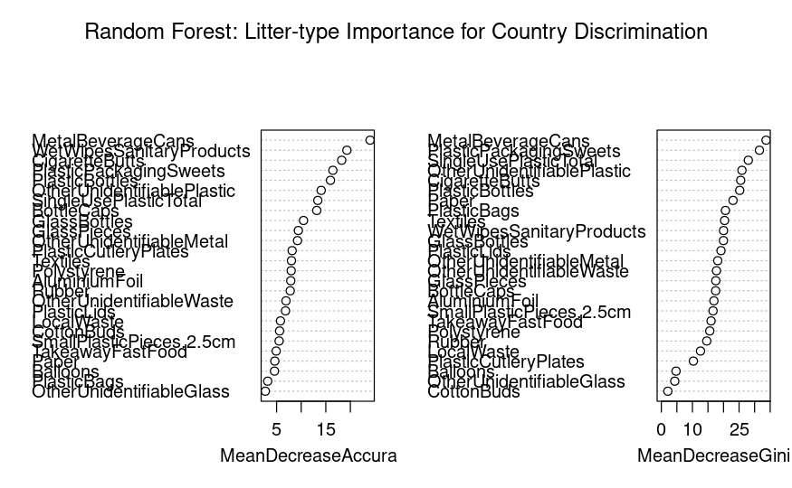

```r
varImpPlot(rf, main="Random Forest: Litter‐type Importance for Country Discrimination")
```

This plot of variable importance importance is telling us:

- A large `MeanDecreaseAccuracy` (**MDA**) means that, when you break the relationship between that predictor and the response, the model’s accuracy suffers a lot → it’s an important predictor for correct country assignments.
- **MDA** is generally the more reliable gauge of predictive importance, since it directly measures impact on OOB‐accuracy.
- A large `MeanDecreaseGini` (**MDG**) means that X frequently appears in high‑up the tree splits and yields big purity gains → it’s structurally important to partitioning the data.
  - **MDG** is faster to compute and tells you which features the trees “prefer” splitting on, but can overweight high–cardinality or continuous variables.

Finally, we will perform a Principal Component Analysis (PCA) to see correlation among litter items and *possible* associations with countries

```r
# ─── 1) PCA (and optional RDA constrained by Country) ───────────────────────────
# 1a) Unconstrained PCA on Hellinger data
# pca1 <- rda(comm_hel)
#
# summary(pca1)
#
# plot(pca1)

# (re)compute PCA with prcomp
pca_prcomp <- prcomp(comm_hel, scale. = TRUE)

#summary(pca_prcomp)
```

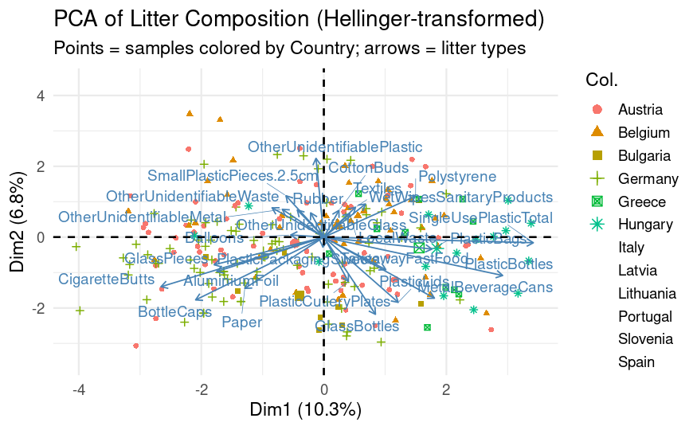

```r
# 1b) Quick biplot via factoextra
PCA_Litter_Country <-
fviz_pca_biplot(pca_prcomp,
                geom.ind    = "point",            # show sites as points
                col.ind     = meta$CountryResponsible %>% str_to_title(),
                palette.ind = "jco",              # color‐blind‐friendly palette
                addEllipses = FALSE,               # 95% CI per country
                label      = "var",               # show arrows for variables
                repel      = TRUE
) +
  labs(title = "PCA of Litter Composition (Hellinger‐transformed)",
       subtitle = "Points = samples colored by Country; arrows = litter types") +
  theme_minimal(base_size = 14)

PCA_Litter_Country
```

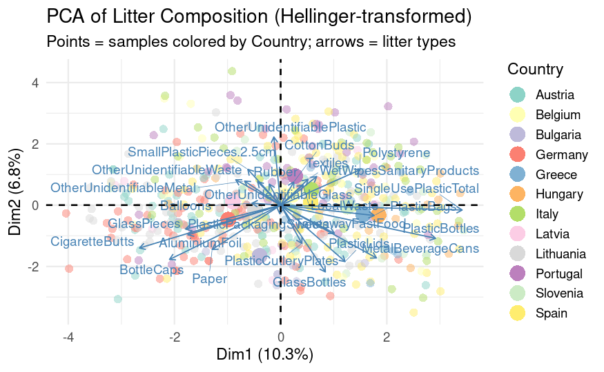

```r
PCA_Litter_Country2 <-
  fviz_pca_biplot(pca_prcomp,
                  geom.ind    = "point",
                  col.ind     = meta$CountryResponsible %>% str_to_title(),
                  palette     = "Set3",  # O prueba: "Paired", "Set1", "Dark2"
                  addEllipses = FALSE,
                  ellipse.type = "confidence",
                  label       = "var",
                  repel       = TRUE,
                  #mean.point  = FALSE,  # Desactiva los centroides (promedio de todos los puntos de cada país)
                  pointsize   = 3,
                  pointshape  = 16,  # Fuerza todos los puntos a círculos
                  alpha.ind   = 0.5  # Transparencia de los puntos (0-1)
  ) +
  labs(title = "PCA of Litter Composition (Hellinger‐transformed)",
       subtitle = "Points = samples colored by Country; arrows = litter types",
       color = "Country") +
  theme_minimal(base_size = 14) +
  guides(fill = "none")  # Quita la leyenda de fill (elipses)

PCA_Litter_Country2
```

And the most important Items for the two forst principal components are:

- First PC

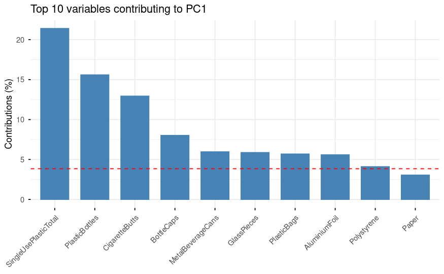

```r
# Bar‐plot of top 10 contributors to PC1
fviz_contrib(pca_prcomp, choice = "var", axes = 1, top = 10) +
  ggtitle("Top 10 variables contributing to PC1")
```

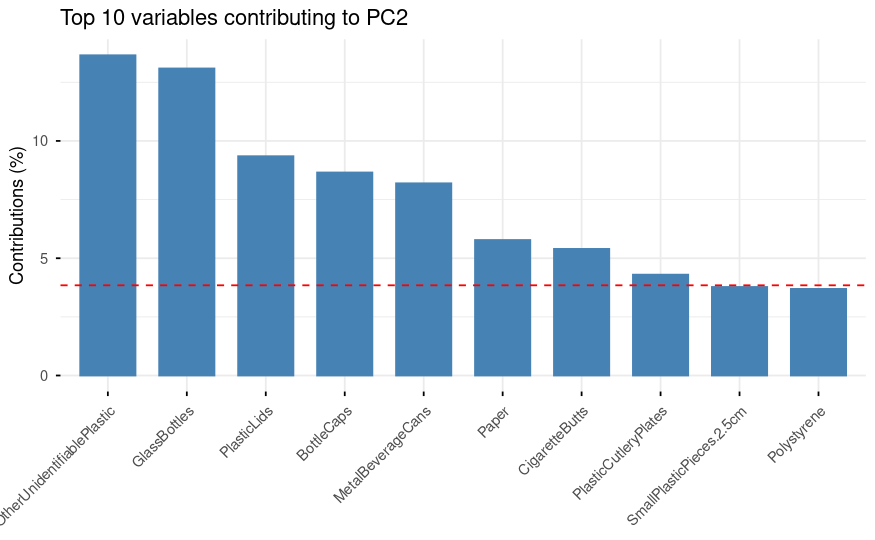

```r
# Bar‐plot of top 10 contributors to PC2
fviz_contrib(pca_prcomp, choice = "var", axes = 2, top = 10) +
  ggtitle("Top 10 variables contributing to PC2")
```

#### Group B: Single Use Plastic - Riverside Waste

Cogeremos el subset de datos que si representan los plásticos de un solo uso (`SUP`) para el grupo B.

```r
# GroupB dataset
GroupB_SingleUsePlastic_data_validated <-
  GroupB_data_validated %>%
  select(DatasetID:Polystyrene) # Seleccionamos metadata y los Single Use Plastic

GroupB_SingleUsePlastic_data_validated
```

| DatasetID | CountryResponsible | SamplingCampaign | SamplingYear | SamplingCoordinatesLatitude | SamplingCoordinatesLongitude | SamplingRiverSystem | SamplingParticipants | RiversideWasteVariety_AttemptedSampling | RiversideWasteVariety_Qualified | PlasticBags | PlasticBottles | PlasticLids | TakeawayFastFood | PlasticCutleryPlates | PlasticPackagingSweets | CottonBuds | WetWipesSanitaryProducts | Polystyrene |
| --- | --- | --- | --- | --- | --- | --- | --- | --- | --- | --- | --- | --- | --- | --- | --- | --- | --- | --- |
| at_6270 | austria | autumn 2022 | 2022 | 48.04275 | 14.4219170 | Danube | 9 | 1 | 1 | 2 | 0 | 0 | 2 | 0 | 1 | 0 | 1 | 0 |
| at_6297 | austria | autumn 2022 | 2022 | 48.26034 | 13.0344048 | Danube | 8 | 1 | 1 | 0 | 1 | 4 | 1 | 1 | 14 | 0 | 3 | 0 |
| at_6382 | austria | autumn 2022 | 2022 | 47.11828 | 13.8141908 | Danube | 20 | 1 | 1 | 0 | 0 | 0 | 0 | 0 | 2 | 0 | 0 | 1 |
| at_6393 | austria | autumn 2022 | 2022 | 46.58301 | 13.8411527 | Danube | 38 | 1 | 1 | 34 | 22 | 13 | 2 | 0 | 34 | 0 | 0 | 0 |
| at_6429 | austria | autumn 2022 | 2022 | 48.21108 | 16.4397350 | Danube | 20 | 1 | 1 | 7 | 22 | 17 | 9 | 3 | 10 | 2 | 7 | 6 |
| at_6429 | austria | autumn 2022 | 2022 | 48.21108 | 16.4397350 | Danube | 20 | 1 | 1 | 7 | 22 | 17 | 9 | 3 | 10 | 2 | 7 | 6 |
| at_6448 | austria | autumn 2022 | 2022 | 46.60477 | 14.2780000 | Danube | 16 | 1 | 1 | 3 | 4 | 1 | 3 | 0 | 1 | 0 | 0 | 0 |
| at_6463 | austria | autumn 2022 | 2022 | 48.12415 | 16.8521211 | Danube | 20 | 1 | 1 | 0 | 16 | 13 | 1 | 0 | 37 | 0 | 1 | 25 |
| at_6463 | austria | autumn 2022 | 2022 | 48.12415 | 16.8521211 | Danube | 20 | 1 | 1 | 0 | 16 | 13 | 1 | 0 | 37 | 0 | 1 | 25 |
| at_6536 | austria | autumn 2022 | 2022 | 47.92751 | 13.7992560 | Danube | 6 | 1 | 1 | 0 | 1 | 1 | 1 | 1 | 2 | 0 | 0 | 0 |

[output cut: 541 more lines]

```r
NA
```

```r
summary(GroupB_SingleUsePlastic_data_validated)
```

```
   DatasetID   CountryResponsible    SamplingCampaign  SamplingYear  SamplingCoordinatesLatitude
 at_6429:  2   lithuania: 90      autumn 2021:  0     Min.   :2022   Min.   :37.18
 at_6463:  2   germany  : 86      autumn 2022:198     1st Qu.:2022   1st Qu.:42.03
 at_6972:  2   spain    : 86      autumn 2023:144     Median :2023   Median :48.07
 at_6977:  2   austria  : 74      autumn 2024: 50     Mean   :2023   Mean   :47.47
 de_6237:  2   italy    : 51      spring 2022:  1     3rd Qu.:2024   3rd Qu.:51.33
 de_6457:  2   belgium  : 49      spring 2023: 26     Max.   :2024   Max.   :57.75
 (Other):539   (Other)  :115      spring 2024:132
 SamplingCoordinatesLongitude SamplingRiverSystem SamplingParticipants RiversideWasteVariety_AttemptedSampling
 Min.   :-9.309               Length:551          Min.   :  2.00       Min.   :1
 1st Qu.: 2.946               Class :character    1st Qu.: 13.00       1st Qu.:1
 Median :12.331               Mode  :character    Median : 19.00       Median :1
 Mean   :10.912                                   Mean   : 19.58       Mean   :1
 3rd Qu.:16.923                                   3rd Qu.: 24.00       3rd Qu.:1
 Max.   :27.488                                   Max.   :250.00       Max.   :1
                                                  NA's   :10
 RiversideWasteVariety_Qualified  PlasticBags      PlasticBottles     PlasticLids      TakeawayFastFood
 Min.   :1                       Min.   :  0.000   Min.   :  0.000   Min.   :  0.000   Min.   :  0.000
 1st Qu.:1                       1st Qu.:  0.000   1st Qu.:  0.000   1st Qu.:  0.000   1st Qu.:  0.000
 Median :1                       Median :  3.000   Median :  1.000   Median :  1.000   Median :  0.000
 Mean   :1                       Mean   :  7.506   Mean   :  6.334   Mean   :  3.991   Mean   :  2.828
 3rd Qu.:1                       3rd Qu.:  7.000   3rd Qu.:  4.000   3rd Qu.:  4.000   3rd Qu.:  2.500
 Max.   :1                       Max.   :196.000   Max.   :576.000   Max.   :115.000   Max.   :102.000

 PlasticCutleryPlates PlasticPackagingSweets   CottonBuds       WetWipesSanitaryProducts  Polystyrene
 Min.   : 0.000       Min.   :  0.000        Min.   :  0.0000   Min.   :   0.00          Min.   :  0.000
 1st Qu.: 0.000       1st Qu.:  1.000        1st Qu.:  0.0000   1st Qu.:   0.00          1st Qu.:  0.000
 Median : 0.000       Median :  4.000        Median :  0.0000   Median :   0.00          Median :  0.000
 Mean   : 1.044       Mean   :  9.984        Mean   :  0.7187   Mean   :  11.97          Mean   :  6.563
 3rd Qu.: 1.000       3rd Qu.: 11.500        3rd Qu.:  0.0000   3rd Qu.:   2.00          3rd Qu.:  2.000
 Max.   :49.000       Max.   :121.000        Max.   :145.0000   Max.   :1897.00          Max.   :423.000
```

###### SUP type abundance

We will obtain the plot for the most common (average abundance) Single Use Plastic type

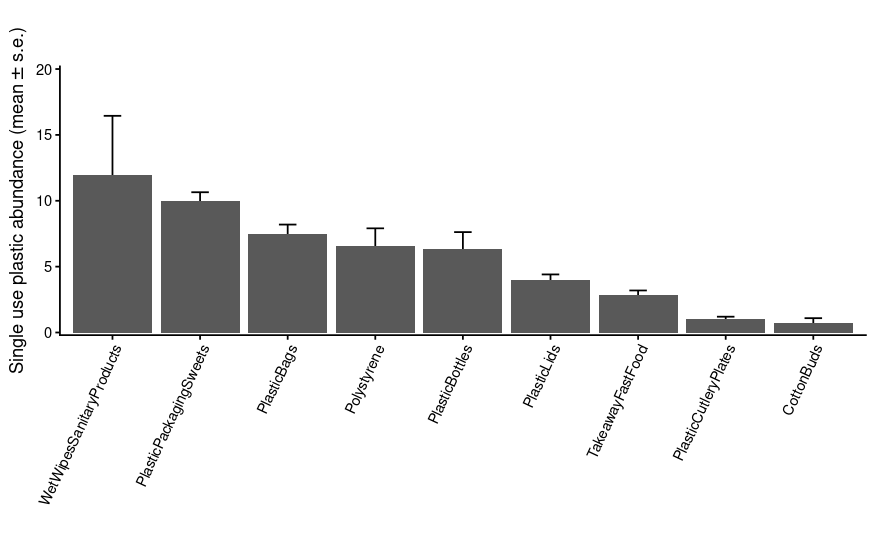

###### SUP type abundance per country

If we now want to visualize the contribution per each country, we have:

[figure not shown]

```r
# Average litter type
SUP_Average_litter_type_country <-
GroupB_SingleUsePlastic_data_validated %>%
  select(CountryResponsible, PlasticBags:Polystyrene) %>%
  pivot_longer(
    PlasticBags:Polystyrene,
    names_to  = "Litter_type",
    values_to = "Abundance"
  ) %>%
  # 1) group by country AND type
  group_by(CountryResponsible, Litter_type) %>%
  summarise(
    Av_Abundance = mean(Abundance, na.rm = TRUE),
    SE_Abundance = sd(Abundance,   na.rm = TRUE) / sqrt(n()),
    .groups = "drop"
  ) %>%
  # title‐case country, reorder types by their overall mean if you like
  mutate(
    CountryResponsible = str_to_title(CountryResponsible),
    #Litter_type       = reorder(Litter_type, -Av_Abundance) # Reordenando el eje X (poco util)
    Litter_type       = Litter_type
  ) %>%
  # 2) plot bars first, then error bars
  ggplot(aes(x = Litter_type, y = Av_Abundance)) +
  geom_col(fill = "lightgray", colour = "black") +
  geom_errorbar(aes(ymin = Av_Abundance - SE_Abundance,
                    ymax = Av_Abundance + SE_Abundance), width = 0.2) +
  facet_wrap(~ CountryResponsible, ncol   = 3, scales = "free_y") +
  labs(x = "", y = expression("Single use plastic abundance (mean" %+-% "s.e.)"), title = '', subtitle = "") +
  # theme_classic() +
  # theme(axis.text.x = element_text(angle = 65, vjust = 1, hjust = 1)) +
  theme_classic(base_size = 16) +
  theme(
    # rotate axis labels, center title, etc.
    axis.text.x     = element_text(angle = 65, hjust = 1),
    plot.title      = element_text(hjust = 0.5),
    strip.background = element_rect(
      fill   = "lightgrey",  # background color
      color  = "black",      # border color
      size   = 0.5           # border thickness
    ),
    strip.text       = element_text(
      colour = "black",      # text color
      face   = "bold"        # make it stand out
    )
  )

SUP_Average_litter_type_country
```

###### SUP type Proportion I - “Across‑type” proportions

- The first approach will be a “*Across‑type*” proportions.
  - For each litter type, what fraction comes from each country? (not from an european total)
  - total abundance of that litter type over each total country.

```r
SUP_Prop_Liter_Country <-
  GroupB_SingleUsePlastic_data_validated %>%
  select(CountryResponsible, PlasticBags:Polystyrene) %>%
  pivot_longer(
    PlasticBags:Polystyrene,
    names_to  = "Litter_type",
    values_to = "Abundance"
  ) %>%
  # 2) sum abundance by (Country, Type)
  group_by(CountryResponsible, Litter_type) %>%
  summarise(
    Total_Abundance = sum(Abundance, na.rm = TRUE),
    .groups = "drop"
  ) %>%
  # 3) compute, per type, the global total
  group_by(Litter_type) %>%
  mutate(
    Global_Total   = sum(Total_Abundance),
    Prop_Country   = Total_Abundance / Global_Total
  ) %>%
  ungroup()

SUP_Prop_Liter_Country
```

| CountryResponsible | Litter_type | Total_Abundance | Global_Total | Prop_Country |
| --- | --- | --- | --- | --- |
| austria | CottonBuds | 6 | 396 | 0.0151515152 |
| austria | PlasticBags | 386 | 4136 | 0.0933268859 |
| austria | PlasticBottles | 263 | 3490 | 0.0753581662 |
| austria | PlasticCutleryPlates | 34 | 575 | 0.0591304348 |
| austria | PlasticLids | 249 | 2199 | 0.1132332879 |
| austria | PlasticPackagingSweets | 736 | 5501 | 0.1337938557 |
| austria | Polystyrene | 259 | 3616 | 0.0716261062 |
| austria | TakeawayFastFood | 130 | 1558 | 0.0834403081 |
| austria | WetWipesSanitaryProducts | 182 | 6598 | 0.0275841164 |
| belgium | CottonBuds | 3 | 396 | 0.0075757576 |

[output cut: 98 more lines]

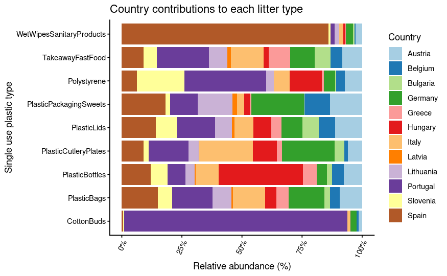

- Now, considering the total of Europe

```r
# 1) Pivot, sum by country & type, then compute each country’s share of the European total
SUP_Data_prop_eu <-
  GroupB_SingleUsePlastic_data_validated %>%
  select(CountryResponsible, PlasticBags:Polystyrene) %>%
  pivot_longer(
    PlasticBags:Polystyrene,
    names_to  = "Litter_type",
    values_to = "Abundance"
  ) %>%
  group_by(CountryResponsible, Litter_type) %>%
  summarise(
    Total_Abundance = sum(Abundance, na.rm = TRUE),
    .groups = "drop"
  ) %>%
  group_by(Litter_type) %>%
  mutate(
    European_Total   = sum(Total_Abundance),
    Prop_of_Europe   = Total_Abundance / European_Total
  ) %>%
  ungroup() %>%
  # optional: title‑case and reorder types by overall Prop for consistent ordering
  mutate(
    CountryResponsible = str_to_title(CountryResponsible),
    Litter_type        = reorder(Litter_type, -Prop_of_Europe)
  )

SUP_Data_prop_eu
```

| CountryResponsible | Litter_type | Total_Abundance | European_Total | Prop_of_Europe |
| --- | --- | --- | --- | --- |
| Austria | CottonBuds | 6 | 396 | 0.0151515152 |
| Austria | PlasticBags | 386 | 4136 | 0.0933268859 |
| Austria | PlasticBottles | 263 | 3490 | 0.0753581662 |
| Austria | PlasticCutleryPlates | 34 | 575 | 0.0591304348 |
| Austria | PlasticLids | 249 | 2199 | 0.1132332879 |
| Austria | PlasticPackagingSweets | 736 | 5501 | 0.1337938557 |
| Austria | Polystyrene | 259 | 3616 | 0.0716261062 |
| Austria | TakeawayFastFood | 130 | 1558 | 0.0834403081 |
| Austria | WetWipesSanitaryProducts | 182 | 6598 | 0.0275841164 |
| Belgium | CottonBuds | 3 | 396 | 0.0075757576 |

[output cut: 98 more lines]

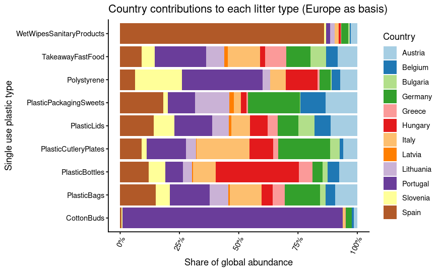

```r
# Example 100%-stacked bar
SUP_Data_prop_eu %>%
mutate(CountryResponsible = str_to_title(CountryResponsible)) %>%
ggplot(., aes(x = Litter_type, y = Prop_of_Europe, fill = CountryResponsible)) +
  geom_col(position = "fill") +
  scale_y_continuous(labels = percent_format()) +
  scale_fill_manual(
    values = brewer.pal(12, "Paired"),
    name   = "Country"
  ) +
  labs(
    x = "Single use plastic type",
    y = "Share of global abundance",
    title = "Country contributions to each litter type (Europe as basis)"
  ) +
  theme_classic() +
  theme(axis.text.x = element_text(angle = 65, hjust = 1)) +
  coord_flip()
```

[figure not shown]

```r
#x11()
# 2) Faceted bar chart of proportion (country share of European total)
# 2) plot with fixed scales and text labels
ggplot(SUP_Data_prop_eu, aes(x = Litter_type, y = Prop_of_Europe)) +
  geom_col(fill = "lightgray", colour = "black") +
  geom_text( # comment if you don't need the numbers above the bars
    #aes(label = percent(Prop_of_Europe, accuracy = 0.1), suffix = "%"),
    aes(label = round((Prop_of_Europe*100), 1)),
    angle   = 45,       # rotate labels 45°
    hjust   = 0,        # left‑align text relative to its anchor
    vjust   = -0.3,     # nudge it a bit above the bar
    size  = 2.7          # adjust text size as needed
  ) +
  scale_y_continuous(
    labels = percent_format(accuracy = 1),
    expand = expansion(mult = c(0, 0.15))  # extra 15% headroom for labels
  ) +
  facet_wrap(~ CountryResponsible, ncol = 3, scales = "fixed") +
  labs(
    x        = NULL,
    y        = "Share of European total (%)",
    title    = "Country contributions to each litter type",
    subtitle = "Proportion of European total abundance for each category"
  ) +
  theme_classic(base_size = 14) +
  theme(
    axis.text.x      = element_text(angle = 65, hjust = 1),
    strip.background = element_rect(fill = "lightgrey", colour = "black"),
    strip.text       = element_text(face = "bold")
  )
```

- HeatMaps

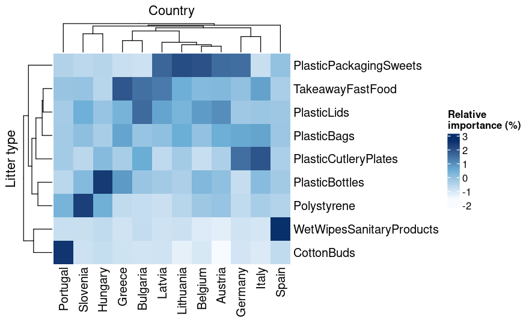

###### SUP type Proportion II - “Within‑country” proportions

- The second approach will be a “*Within‑country*” proportions.
  - For each country, what fraction of its total litter is each type?
  - Total abundance of all types in that country.

```r
SUP_Prop_Liter_Country2 <-
  GroupB_SingleUsePlastic_data_validated %>%
  select(CountryResponsible, PlasticBags:Polystyrene) %>%
  pivot_longer(
    PlasticBags:Polystyrene,
    names_to  = "Litter_type",
    values_to = "Abundance"
  ) %>%
  # 2) sum by (Country, Type)
  group_by(CountryResponsible, Litter_type) %>%
  summarise(
    Total_Abundance = sum(Abundance, na.rm = TRUE),
    .groups = "drop"
  ) %>%
  # 3) compute, per country, that country’s total
  group_by(CountryResponsible) %>%
  mutate(
    Country_Total = sum(Total_Abundance),
    Prop_Type     = Total_Abundance / Country_Total
  ) %>%
  ungroup()

SUP_Prop_Liter_Country2
```

| CountryResponsible | Litter_type | Total_Abundance | Country_Total | Prop_Type |
| --- | --- | --- | --- | --- |
| austria | CottonBuds | 6 | 2245 | 0.0026726058 |
| austria | PlasticBags | 386 | 2245 | 0.1719376392 |
| austria | PlasticBottles | 263 | 2245 | 0.1171492205 |
| austria | PlasticCutleryPlates | 34 | 2245 | 0.0151447661 |
| austria | PlasticLids | 249 | 2245 | 0.1109131403 |
| austria | PlasticPackagingSweets | 736 | 2245 | 0.3278396437 |
| austria | Polystyrene | 259 | 2245 | 0.1153674833 |
| austria | TakeawayFastFood | 130 | 2245 | 0.0579064588 |
| austria | WetWipesSanitaryProducts | 182 | 2245 | 0.0810690423 |
| belgium | CottonBuds | 3 | 1319 | 0.0022744503 |

[output cut: 98 more lines]

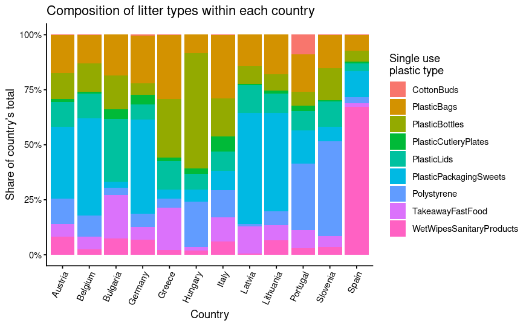

```r
# Example 100%-stacked bar per country
SUP_Prop_Liter_Country2 %>%
mutate(CountryResponsible = str_to_title(CountryResponsible)) %>%
ggplot(., aes(x = CountryResponsible, y = Prop_Type, fill = Litter_type)) +
  geom_col(position = "fill") +
  scale_y_continuous(labels = percent_format()) +
  labs(
    x = "Country",
    y = "Share of country’s total",
    title = "Composition of litter types within each country",
    fill = "Single use \nplastic type"
  ) +
  theme_classic() +
  theme(axis.text.x = element_text(angle = 65, hjust = 1))
```

[figure not shown]

```r
  # 2) plot bars first, then error bars
SUP_Prop_Liter_Country2 %>%
  # 1) group by country AND type
  group_by(CountryResponsible, Litter_type) %>%
  summarise(
    Av_Proportion = mean(Prop_Type, na.rm = TRUE),
    SE_Proportion = sd(Prop_Type,   na.rm = TRUE) / sqrt(n()),
    .groups = "drop"
  ) %>%
  # title‐case country, reorder types by their overall mean if you like
  mutate(
    CountryResponsible = str_to_title(CountryResponsible),
    Litter_type       = reorder(Litter_type, -Av_Proportion)
  ) %>%
  ggplot(data = ., aes(x = Litter_type, y = Av_Proportion)) +
  geom_col(fill = "lightgray", colour = "black") +
  geom_errorbar(aes(ymin = Av_Proportion - SE_Proportion,
                    ymax = Av_Proportion + SE_Proportion), width = 0.2) +
  facet_wrap(~ CountryResponsible, ncol   = 3, scales = "free_y") +
  labs(x = "", y = expression("Single use plastic abundance (mean" %+-% "s.e.)"), title = '', subtitle = "") +
  # theme_classic() +
  # theme(axis.text.x = element_text(angle = 65, vjust = 1, hjust = 1)) +
  theme_classic(base_size = 16) +
  theme(
    # rotate axis labels, center title, etc.
    axis.text.x     = element_text(angle = 65, hjust = 1),
    plot.title      = element_text(hjust = 0.5),
    strip.background = element_rect(
      fill   = "lightgrey",  # background color
      color  = "black",      # border color
      size   = 0.5           # border thickness
    ),
    strip.text       = element_text(
      colour = "black",      # text color
      face   = "bold"        # make it stand out
    )
  )
```

###### SUP Multivariate Perspective

```r
# assume your data is in a data.frame called `df`
# and has at least:
#   CountryResponsible | PlasticBags | PlasticBottles | ... | LocalWaste

df_SUP <- GroupB_SingleUsePlastic_data_validated %>%
  select(CountryResponsible, PlasticBags:Polystyrene)
# %>%
# #drop_na()
# mutate_all(funs(replace_na(.,0)))

# isolate metadata + community matrix
meta_SUP <- df_SUP %>% select(CountryResponsible)
comm_SUP <- df_SUP %>% select(-CountryResponsible)

# Hellinger‐transform community data (recommended for PCA/cluster/PERMANOVA)
comm_hel_SUP <- decostand(comm, method = "hellinger")
```

In order to see if there are significant differences across country in the community composition, we will perform a PERMANOVA test:

```r
# 2a) Compute distance and hierarchical clustering (Ward’s D2)
dist_mat_SUP <- vegdist(comm_hel_SUP, method = "euclid")

# 3a) PERMANOVA: test if composition differs by Country
set.seed(42)

perm1_SUP <- adonis2(dist_mat_SUP ~ CountryResponsible, data = meta,
                 permutations = 999, by = "margin")
print(perm1_SUP)
```

```
Permutation test for adonis under reduced model
Marginal effects of terms
Permutation: free
Number of permutations: 999

adonis2(formula = dist_mat_SUP ~ CountryResponsible, data = meta, permutations = 999, by = "margin")
                    Df SumOfSqs      R2      F Pr(>F)
CountryResponsible  11   22.479 0.09759 5.2992  0.001 ***
Residual           539  207.854 0.90241
Total              550  230.333 1.00000
---
Signif. codes:  0 ‘***’ 0.001 ‘**’ 0.01 ‘*’ 0.05 ‘.’ 0.1 ‘ ’ 1
```

So, we conclude that there are significant differences among countries. but What are the items that explains these differences?

The answer will be addressed by performing a **Multivariate Random Forest**.

```r
# 3b) Multivariate Random Forest:
#     predict Country from composition → variable importance
rf_SUP <- randomForest(
  x      = comm_hel_SUP,
  y      = as.factor(meta_SUP$CountryResponsible),
  ntree  = 500,
  importance = TRUE
)

print(rf_SUP)
```

```
Call:
 randomForest(x = comm_hel_SUP, y = as.factor(meta_SUP$CountryResponsible),      ntree = 500, importance = TRUE)
               Type of random forest: classification
                     Number of trees: 500
No. of variables tried at each split: 5

        OOB estimate of  error rate: 64.43%
Confusion matrix:
          austria belgium bulgaria germany greece hungary italy latvia lithuania portugal slovenia spain class.error
austria        29       2        0      14      0       0     3      0         7        0        0    19   0.6081081
belgium         7       7        0       4      0       0     2      1        10        2        1    15   0.8571429
bulgaria        1       0        9       0      0       0     0      0         0        0        0     0   0.1000000
germany        13       2        0      39      0       0     2      0        20        4        0     6   0.5465116
greece          1       0        0       0      0       0     6      0         0        1        1     2   1.0000000
hungary         1       1        1       1      0       3     1      0         0        0        0     7   0.8000000
italy           9       4        0       5      0       1    19      0         3        2        1     7   0.6274510
latvia          0       0        0       4      0       0     0      0         4        0        0     2   1.0000000
lithuania       7       4        0      26      0       0     1      0        40        1        0    11   0.5555556
portugal        6       3        0       7      0       0     7      0         9        8        1     4   0.8222222
slovenia        2       1        0       0      0       0     4      0         1        3        3    10   0.8750000
spain          14       5        0       8      0       1     7      2        10        0        0    39   0.5465116
```

The estimated error rate (OOB) is high, so conclusion have to be taken with care. Thus, the more important (differential across countries) litter components are:

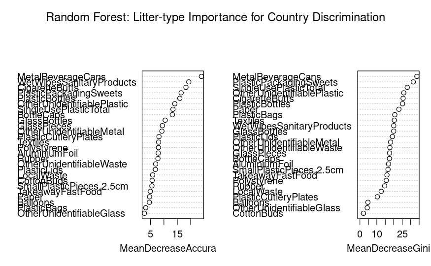

```r
varImpPlot(rf_SUP, main="Random Forest: Litter‐type Importance for Country Discrimination")
```

This plot of variable importance importance is telling us:

- A large `MeanDecreaseAccuracy` (**MDA**) means that, when you break the relationship between that predictor and the response, the model’s accuracy suffers a lot → it’s an important predictor for correct country assignments.
- **MDA** is generally the more reliable gauge of predictive importance, since it directly measures impact on OOB‐accuracy.
- A large `MeanDecreaseGini` (**MDG**) means that X frequently appears in high‑up the tree splits and yields big purity gains → it’s structurally important to partitioning the data.
  - **MDG** is faster to compute and tells you which features the trees “prefer” splitting on, but can overweight high–cardinality or continuous variables.

Finally, we will perform a Principal Component Analysis (PCA) to see correlation among litter items and *possible* associations with countries

```r
# ─── 1) PCA (and optional RDA constrained by Country) ───────────────────────────
# 1a) Unconstrained PCA on Hellinger data
# pca1 <- rda(comm_hel)
#
# summary(pca1)
#
# plot(pca1)

# (re)compute PCA with prcomp
pca_prcomp_SUP <- prcomp(comm_hel_SUP, scale. = TRUE)

#summary(pca_prcomp_SUP)
```

```r
# # 1b) Quick biplot via factoextra
# SUP_PCA_Litter_Country <-
# fviz_pca_biplot(pca_prcomp_SUP,
#                 geom.ind    = "point",            # show sites as points
#                 col.ind     = meta_SUP$CountryResponsible %>% str_to_title(),
#                 palette.ind = "jco",              # color‐blind‐friendly palette
#                 addEllipses = FALSE,               # 95% CI per country
#                 label      = "var",               # show arrows for variables
#                 repel      = TRUE
# ) +
#   labs(title = "PCA of Litter Composition (Hellinger‐transformed)",
#        subtitle = "Points = samples colored by Country; arrows = Single use plastic types") +
#   theme_minimal(base_size = 14)
#
# SUP_PCA_Litter_Country
```

[figure not shown]

```r
SUP_PCA_Litter_Country2 <-
  fviz_pca_biplot(pca_prcomp_SUP,
                  geom.ind    = "point",
                  col.ind     = meta_SUP$CountryResponsible %>% str_to_title(),
                  palette     = "Set3",  # O prueba: "Paired", "Set1", "Dark2"
                  addEllipses = FALSE,
                  ellipse.type = "confidence",
                  label       = "var",
                  repel       = TRUE,
                  #mean.point  = FALSE,  # Desactiva los centroides (promedio de todos los puntos de cada país)
                  pointsize   = 3,
                  pointshape  = 16,  # Fuerza todos los puntos a círculos
                  alpha.ind   = 0.5  # Transparencia de los puntos (0-1)
  ) +
  labs(title = "PCA of Litter Composition (Hellinger‐transformed)",
       subtitle = "Points = samples colored by Country; arrows = Single use plastic types",
       color = "Country") +
  theme_minimal(base_size = 14) +
  guides(fill = "none")  # Quita la leyenda de fill (elipses)

SUP_PCA_Litter_Country2
```

And the most important Items for the two forst principal components are:

- First PC

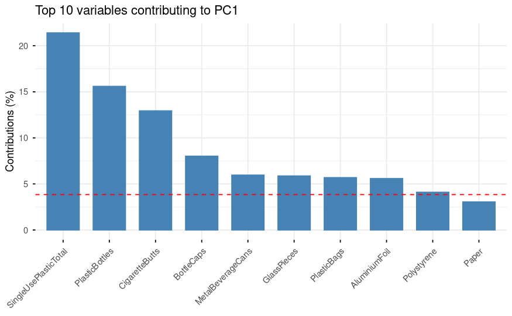

```r
# Bar‐plot of top 10 contributors to PC1
fviz_contrib(pca_prcomp_SUP, choice = "var", axes = 1, top = 10) +
  ggtitle("Top 10 variables contributing to PC1")
```

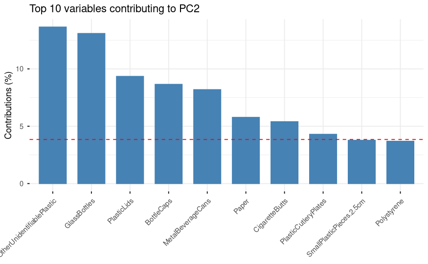

```r
# Bar‐plot of top 10 contributors to PC2
fviz_contrib(pca_prcomp_SUP, choice = "var", axes = 2, top = 10) +
  ggtitle("Top 10 variables contributing to PC2")
```